# Classifying barbell lifts

## Practical Machine Learning Peer Assessment

### July 2014

## Introduction

Using devices such as Jawbone Up, Nike FuelBand, and Fitbit it is now possible to collect a large amount of data about personal activity relatively inexpensively. One thing that people regularly do is quantify how much of a particular activity they do, but they rarely quantify how well they do it. Here we will investigate a dataset where 6 participants were asked to perform barbell lifts correctly and incorrectly in 5 different ways, with accelerometers on the belt, forearm, arm, and dumbell. We build a classification model that can classify which way the participant is lifting the barbell, and then check this classification model against a test data set. More information about this dataset is available from the website (1) specifically the section on the Weight Lifting Exercise Dataset. The training data set(2) and the testing data set (3) are also available.

## Methods

### Getting and preparing the data

First we load the training and testing data sets. Here it was necessary to pay attention to the fact that missing values could be represented in several ways, either by an `NA`, a totally empty value or `#DIV/0!` indicating a divide by zero error. In order to avoid numerical variables being erroneously converted to factor variables it was necessary to convert these values explicitly to NAs:

```r
train <- read.csv("data/pml-training.csv", na.strings = c("NA", "", "#DIV/0!"))
test <- read.csv("data/pml-testing.csv", na.strings = c("NA", "", "#DIV/0!"))
summary(train$classe)
```

```
##    A    B    C    D    E
## 5580 3797 3422 3216 3607
```

Second, examining the dataset, it is apparent that the different values of `classe` are grouped in sequential order so a model could appear to do very well just based on the index. Therefore it is important to remove the id column, `x`, and any other column which could be used to place the values is sequential order such as timestamps. Also the names of the people who supplied the data are also grouped in sequential order so they need to be removed as well:

```r
drops <- c("user_name", "raw_timestamp_part_1", "raw_timestamp_part_2", "cvtd_timestamp",
    "X", "new_window")
train.k <- train[, !(names(train) %in% drops)]
test.k <- test[, !(names(test) %in% drops)]
```

Third, examining the dataset it was apparent that some columns had a lot of missing values, so we calculate how many missing values each column has and remove any columns that have too many missing values:

```r
n <- dim(train.k)[2]
naCols <- vector(length = n)
for (i in 1:n) {
    naCols[i] <- sum(is.na(train.k[, i]))
}
train.s <- train.k[, which(naCols < 10)]
test.s <- test.k[, which(naCols < 10)]
```

Fourth, we we subdivide the training set to create a cross validation set. We allocate 70% of the original training set to the new training set, and the other 30% to the cross validation set:

```r
library(caret)
inTrain <- createDataPartition(y = train.s$classe, p = 0.7, list = FALSE)
training <- train.s[inTrain, ]
train.cv <- train.s[-inTrain, ]
```

### Classification and regression trees

First we will investigate using classification and regression trees as proposed by Breiman (4) and Ripley (5):

```r
library(tree)
fit1 <- tree(classe ~ ., method = "tree", data = training)
p1 <- predict(fit1, type = "class")
table(training$classe, p1)
```

```
##    p1
##        A    B    C    D    E
##   A 3402  121   26  305   52
##   B  249 1593  118  588  110
##   C   16   92 1975  301   12
##   D   30  194  499 1497   32
##   E   96  190  159  546 1534
```

```r
fit1.prune <- prune.misclass(fit1, best = 10)
```

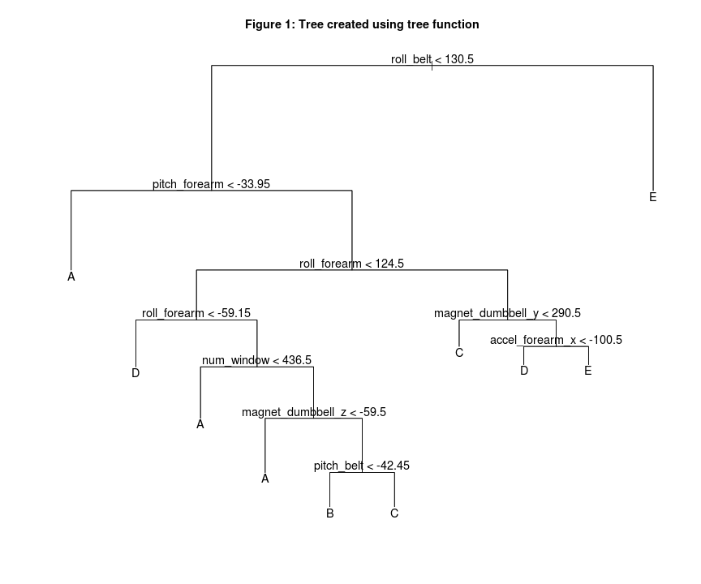

```r
plot(fit1.prune)
title(main = "Figure 1: Tree created using tree function")
text(fit1.prune, cex = 1.2)
```

Does this complexity mean the tree is overfitting? We will investigate this using pruning. First though, we will estimate the in-sample error:

```r
nright = table(p1 == training$classe)
tree_in_error = as.vector(100 * (1 - nright["TRUE"]/sum(nright)))
```

We estimate the in-sample error to be **27.1966 %**. Next, how does the tree perform on cross-validation set?

```r
p2 <- predict(fit1, newdata = train.cv, type = "class")
table(train.cv$classe, p2)
```

```
##    p2
##        A    B    C    D    E
##   A 1428   51   15  156   24
##   B  100  699   52  236   52
##   C    6   50  839  126    5
##   D   11   92  213  637   11
##   E   39   76   54  243  670
```

```r
nright = table(p2 == train.cv$classe)
tree_out_error = as.vector(100 * (1 - nright["TRUE"]/sum(nright)))
```

We estimate the out-of-sample error to be **27.3917 %**. Can we improve performance on cross-validation set by pruning?

```r
error.cv <- {
    Inf
}
for (i in 2:19) {
    prune.data <- prune.misclass(fit1, best = i)
    pred.cv <- predict(prune.data, newdata = data.cv, type = "class")
    nright = table(pred.cv == data.cv$classe)
    error = as.vector(100 * (1 - nright["TRUE"]/sum(nright)))
    error.cv <- c(error.cv, error)
}
error.cv
```

```
##  [1]   Inf 63.31 56.28 56.28 53.44 45.28 45.28 45.28 42.62 40.65 39.00
## [12] 35.62 35.62 32.59 32.59 31.49 30.50 29.65 28.87
```

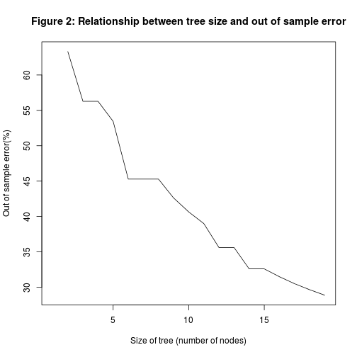

```r
plot(error.cv, type = "l", xlab = "Size of tree (number of nodes)", ylab = "Out of sample error(%)",
    main = "Figure 2: Relationship between tree size and out of sample error")
```

Despite the complexity of the tree in Figure 1, Figure 2 does not indicate overfitting as the out of sample error does not increase as more nodes are added to the tree, in fact it seems to indicate the tree is not sufficiently complex.

### RPart trees

Next we will use a different type of classification and regression tree implemented by rpart, also as proposed by as proposed by Breiman (4):

```r
fit2 <- rpart(classe ~ ., data = training)
p3 <- predict(fit2, type = "class")
table(training$classe, p3)
```

```
##    p3
##        A    B    C    D    E
##   A 3527  117   43  174   45
##   B  471 1587  172  246  182
##   C   91   81 1831  237  156
##   D  139  192  325 1352  244
##   E  116  269  218  114 1808
```

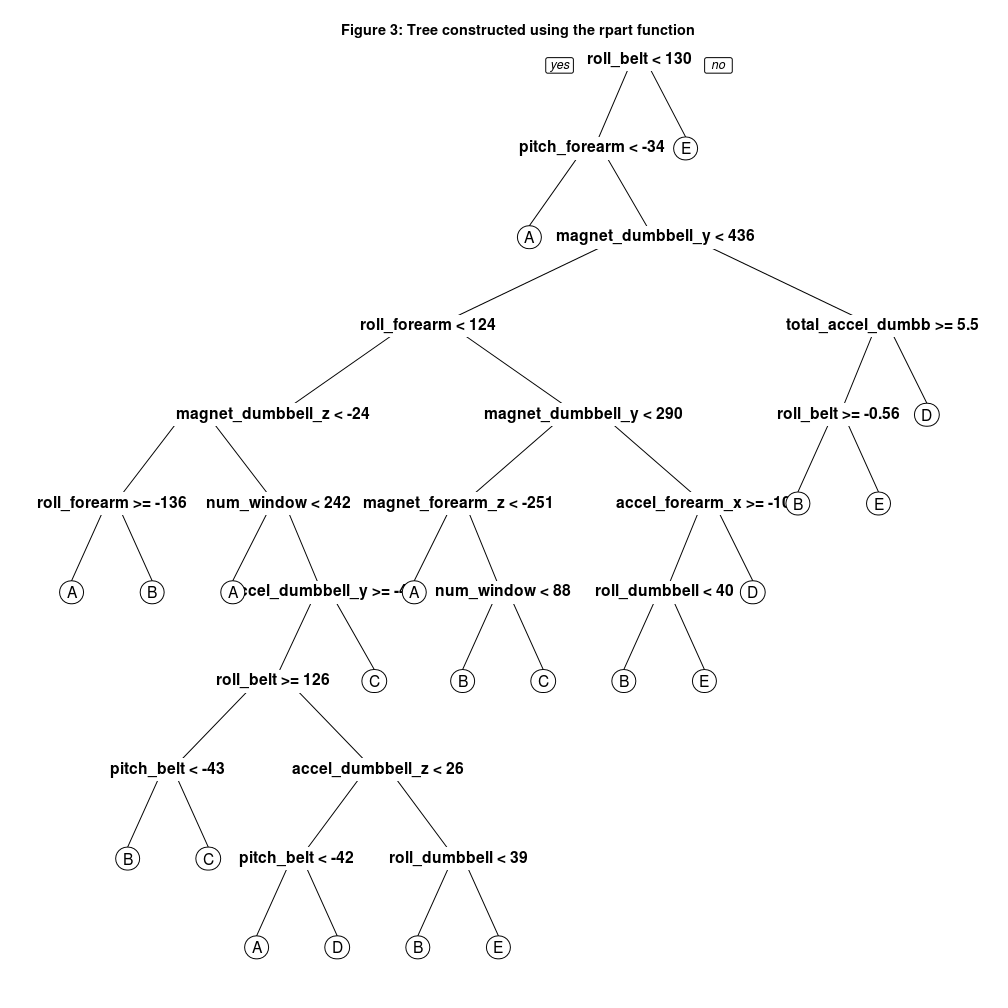

```r
library(rpart.plot)
prp(fit2, cex = 1.3)
title(main = "Figure 3: Tree constructed using the rpart function")
```

Looking at the trees in Figure 1 and Figure 3 there are similarities between them.

[figure not shown]

```r
cp <- fit2$cp
plot(cp[, 2], cp[, 3], xlab = "Size of tree (number of nodes", ylab = "Out of sample error (%)",
    main = "Figure 4: Relationship between tree size and out of sample error")
```

Next we estimate the in-sample error:

```r
nright = table(p3 == training$classe)
rpart_in_error = as.vector(100 * (1 - nright["TRUE"]/sum(nright)))
```

```r
p4 <- predict(fit2, newdata = train.cv, type = "class")
table(train.cv$classe, p4)
```

```
##    p4
##        A    B    C    D    E
##   A 1468   78   16   90   22
##   B  175  701   67  113   83
##   C   59   41  753  117   56
##   D   73   81  137  558  115
##   E   56  118   70   51  787
```

```r
nright = table(p4 == train.cv$classe)
rpart_out_error = as.vector(100 * (1 - nright["TRUE"]/sum(nright)))
```

### Random forests

Next we apply random forests also proposed by Breiman (6) and Breiman (7):

```r
library(randomForest)
fit3 <- randomForest(classe ~ ., data = training, method = "class")
p5 <- predict(fit3, type = "class")
table(training$classe, p5)
```

```
##    p5
##        A    B    C    D    E
##   A 3906    0    0    0    0
##   B    6 2650    2    0    0
##   C    0   15 2381    0    0
##   D    0    0   14 2237    1
##   E    0    0    0    3 2522
```

```r
nright = table(p5 == training$classe)
forest_in_error = as.vector(100 * (1 - nright["TRUE"]/sum(nright)))
```

The in-sample error for the random forest is **0.2985 %**. This is a big improvement over the two previous tree based methods. How does the forest perform on cross-validation set?

```r
p6 <- predict(fit3, newdata = train.cv, type = "class")
table(data.cv$classe, p6)
```

```
##    p6
##        A    B    C    D    E
##   A 1674    0    0    0    0
##   B    2 1136    1    0    0
##   C    0    8 1018    0    0
##   D    0    0    3  960    1
##   E    0    0    0    0 1082
```

```r
nright = table(p6 == train.cv$classe)
forest_out_error = as.vector(100 * (1 - nright["TRUE"]/sum(nright)))
```

The out-of-sample error for the random forest is **0.2549 %**. Again this is much better than the previous tree based methods.

## Results

```r
destDir = "./output"
pml_write_files = function(x) {
    n = length(x)
    for (i in 1:n) {
        filename = paste0(destDir, "/", "problem_id_", i, ".txt")
        write.table(x[i], file = filename, quote = FALSE, row.names = FALSE,
            col.names = FALSE)
    }
}
if (!file.exists(destDir)) {
    dir.create(destDir)
}
p2 <- predict(fit2, newdata = test.s, type = "class")
pml_write_files(p2)
```

## References

[1] Dataset http://groupware.les.inf.puc-rio.br/har

[2] Training data set https://d396qusza40orc.cloudfront.net/predmachlearn/pml-training.csv

[3] Testing data set https://d396qusza40orc.cloudfront.net/predmachlearn/pml-testing.csv

[4] Breiman L., Friedman J. H., Olshen R. A., and Stone, C. J. (1984), Classification and Regression Trees. Wadsworth.

[5] Ripley, B. D. (1996), Pattern Recognition and Neural Networks., Cambridge University Press, Cambridge. Chapter 7.

[6] Breiman, L. (2001), Random Forests, Machine Learning 45(1), 5-32.

[7] Breiman, L (2002), Manual On Setting Up, Using, And Understanding Random Forests V3.1, http://oz.berkeley.edu/users/breiman/Using_random_forests_V3.1.pdf